# Proteomics Volcano Plot

Analyse the input data from the cytoscape session:

1. Clean up the protein-protein transcriptomic dataset
2. Generate volcano plots
3. ???

## Yeast Protein-Protein Network

Load the tidyverse package:

```r
suppressMessages(library(tidyverse))
```

The data is in an Excel spreadsheet. It used to be difficult to load Excel files into R, now it’s fairly simple with `read_excel` from the `readxl` package.

The experimental design for this dataset is two drug treatments (AMB, AMB-LF) and a control condition. The spreadsheet contains the results of either drug treatment compared to the control condition (ie. logFC for AMB vs control or logFC for AMB-LF vs control). The results for each comparison is stored in a seperated sheet in the `Table_1_edited.xlsx`.

Those two sheets can be read in two different data-frame objects. However, the logFC and FDR columns are named differently across the two sheets, despite containing the same pieces of information. If we rename these columns, we can combine the two experimental results together into one data-frame, with the treatment column tracking which values belong to which experiment. This means any data clean up step we apply only needs to be applied to one datafrane, rather than manipulating both data-frames at the same time.

```r
# Create a vector of strings to use as column names
new_cols <- c("treatment", "oln_id", "logFC", "FDR", "gene_name", "sgd_description", "scer_uniprot_description",
              "uniprot_acc")

sheet1_xls <- readxl::read_excel("data/Table_1_edited.xlsx", sheet = "AMB", col_names = new_cols, skip = 1)
sheet2_xls <- readxl::read_excel("data/Table_1_edited.xlsx", sheet = "AMB_LF", col_names = new_cols, skip = 1)

table_1 <- rbind(sheet1_xls, sheet2_xls)
```

We can examine our combined dataset with `View()`

```r
View(table_1)
```

| treatment | oln_id | logFC | FDR | gene_name | sgd_description | scer_uniprot_description | uniprot_acc |
| --- | --- | --- | --- | --- | --- | --- | --- |
| AMB | YER069W | 2.051516 | 4.120477e-10 | ARG5,6 | Acetylglutamate kinase and N-acetyl-gamma-glutamyl-phosphate reductase; N-acetyl-L-glutamate kinase (NAGK) catalyzes the 2nd and N-acetyl-gamma-glutamyl-phosphate reductase (NAGSA), the 3rd step in ar… | Protein ARG5,6, mitochondrial [Cleaved into: N-acetyl-gamma-glutamyl-phosphate reductase (EC 1.2.1.38) (N-acetyl-glutamate semialdehyde dehydrogenase) (NAGSA dehydrogenase); Acetylglutamate kinase (EC… | Q01217 |
| AMB | YGL117W | 2.437640 | 6.098768e-10 | NA | Putative protein of unknown function | Uncharacterized protein YGL117W | P53133 |
| AMB | YDL170W | 2.012645 | 3.091202e-09 | UGA3 | Transcriptional activator for GABA-dependent induction of GABA genes; binds to DNA elements found in the promoters of target genes and increases their expression in the presence of GABA (gamma-aminobu… | Transcriptional activator protein UGA3 | P26370 |
| AMB | YDR354W | 1.373163 | 8.696343e-09 | TRP4 | Anthranilate phosphoribosyl transferase; transferase of the tryptophan biosynthetic pathway; catalyzes the phosphoribosylation of anthranilate; subject to the general control system of amino acid bios… | Anthranilate phosphoribosyltransferase (EC 2.4.2.18) | P07285 |
| AMB | YER175C | 2.391453 | 1.146598e-08 | TMT1 | Trans-aconitate methyltransferase; cytosolic enzyme that catalyzes the methyl esterification of 3-isopropylmalate, an intermediate of the leucine biosynthetic pathway, and trans-aconitate, which inhib… | Trans-aconitate 3-methyltransferase (EC 2.1.1.145) | P32643 |
| AMB | YBR145W | 1.837643 | 1.146598e-08 | ADH5 | Alcohol dehydrogenase isoenzyme V; involved in ethanol production; ADH5 has a paralog, ADH1, that arose from the whole genome duplication | Alcohol dehydrogenase 5 (EC 1.1.1.1) (Alcohol dehydrogenase V) | P38113 |
| AMB | YBR145W | 1.837643 | 1.146598e-08 | ADH5 | Alcohol dehydrogenase isoenzyme V; involved in ethanol production; ADH5 has a paralog, ADH1, that arose from the whole genome duplication | Alcohol dehydrogenase 5 (EC 1.1.1.1) (Alcohol dehydrogenase V) | P38113 |
| AMB | YBR145W | 1.837643 | 1.146598e-08 | ADH5 | Alcohol dehydrogenase isoenzyme V; involved in ethanol production; ADH5 has a paralog, ADH1, that arose from the whole genome duplication | Alcohol dehydrogenase 5 (EC 1.1.1.1) (Alcohol dehydrogenase V) | P38113 |
| AMB | YBR145W | 1.837643 | 1.146598e-08 | ADH5 | Alcohol dehydrogenase isoenzyme V; involved in ethanol production; ADH5 has a paralog, ADH1, that arose from the whole genome duplication | Alcohol dehydrogenase 5 (EC 1.1.1.1) (Alcohol dehydrogenase V) | P38113 |
| AMB | YBR145W | 1.837643 | 1.146598e-08 | ADH5 | Alcohol dehydrogenase isoenzyme V; involved in ethanol production; ADH5 has a paralog, ADH1, that arose from the whole genome duplication | Alcohol dehydrogenase 5 (EC 1.1.1.1) (Alcohol dehydrogenase V) | P38113 |

[output cut: 30 more lines]

Examining the dataset shows that there are duplicated rows in this dataset. For example:

```r
table_1 %>% filter(gene_name == "ADH5")
```

| treatment | oln_id | logFC | FDR | gene_name | sgd_description | scer_uniprot_description | uniprot_acc |
| --- | --- | --- | --- | --- | --- | --- | --- |
| AMB | YBR145W | 1.837643 | 1.146598e-08 | ADH5 | Alcohol dehydrogenase isoenzyme V; involved in ethanol production; ADH5 has a paralog, ADH1, that arose from the whole genome duplication | Alcohol dehydrogenase 5 (EC 1.1.1.1) (Alcohol dehydrogenase V) | P38113 |
| AMB | YBR145W | 1.837643 | 1.146598e-08 | ADH5 | Alcohol dehydrogenase isoenzyme V; involved in ethanol production; ADH5 has a paralog, ADH1, that arose from the whole genome duplication | Alcohol dehydrogenase 5 (EC 1.1.1.1) (Alcohol dehydrogenase V) | P38113 |
| AMB | YBR145W | 1.837643 | 1.146598e-08 | ADH5 | Alcohol dehydrogenase isoenzyme V; involved in ethanol production; ADH5 has a paralog, ADH1, that arose from the whole genome duplication | Alcohol dehydrogenase 5 (EC 1.1.1.1) (Alcohol dehydrogenase V) | P38113 |
| AMB | YBR145W | 1.837643 | 1.146598e-08 | ADH5 | Alcohol dehydrogenase isoenzyme V; involved in ethanol production; ADH5 has a paralog, ADH1, that arose from the whole genome duplication | Alcohol dehydrogenase 5 (EC 1.1.1.1) (Alcohol dehydrogenase V) | P38113 |
| AMB | YBR145W | 1.837643 | 1.146598e-08 | ADH5 | Alcohol dehydrogenase isoenzyme V; involved in ethanol production; ADH5 has a paralog, ADH1, that arose from the whole genome duplication | Alcohol dehydrogenase 5 (EC 1.1.1.1) (Alcohol dehydrogenase V) | P38113 |
| AMB-LF | YBR145W | 1.529729 | 1.265698e-07 | ADH5 | Alcohol dehydrogenase isoenzyme V; involved in ethanol production; ADH5 has a paralog, ADH1, that arose from the whole genome duplication | Alcohol dehydrogenase 5 (EC 1.1.1.1) (Alcohol dehydrogenase V) | P38113 |
| AMB-LF | YBR145W | 1.529729 | 1.265698e-07 | ADH5 | Alcohol dehydrogenase isoenzyme V; involved in ethanol production; ADH5 has a paralog, ADH1, that arose from the whole genome duplication | Alcohol dehydrogenase 5 (EC 1.1.1.1) (Alcohol dehydrogenase V) | P38113 |
| AMB-LF | YBR145W | 1.529729 | 1.265698e-07 | ADH5 | Alcohol dehydrogenase isoenzyme V; involved in ethanol production; ADH5 has a paralog, ADH1, that arose from the whole genome duplication | Alcohol dehydrogenase 5 (EC 1.1.1.1) (Alcohol dehydrogenase V) | P38113 |
| AMB-LF | YBR145W | 1.529729 | 1.265698e-07 | ADH5 | Alcohol dehydrogenase isoenzyme V; involved in ethanol production; ADH5 has a paralog, ADH1, that arose from the whole genome duplication | Alcohol dehydrogenase 5 (EC 1.1.1.1) (Alcohol dehydrogenase V) | P38113 |
| AMB-LF | YBR145W | 1.529729 | 1.265698e-07 | ADH5 | Alcohol dehydrogenase isoenzyme V; involved in ethanol production; ADH5 has a paralog, ADH1, that arose from the whole genome duplication | Alcohol dehydrogenase 5 (EC 1.1.1.1) (Alcohol dehydrogenase V) | P38113 |

We can remove duplicate rows:

```r
distinct_df <- table_1 %>% distinct()
print(paste("There are", nrow(table_1), "total rows and", nrow(distinct_df), "distinct rows"))
```

```
## [1] "There are 13800 total rows and 12014 distinct rows"
```

Double check how many results for ADH5:

```r
distinct_df %>% filter(gene_name == "ADH5")
```

| treatment | oln_id | logFC | FDR | gene_name | sgd_description | scer_uniprot_description | uniprot_acc |
| --- | --- | --- | --- | --- | --- | --- | --- |
| AMB | YBR145W | 1.837643 | 1.146598e-08 | ADH5 | Alcohol dehydrogenase isoenzyme V; involved in ethanol production; ADH5 has a paralog, ADH1, that arose from the whole genome duplication | Alcohol dehydrogenase 5 (EC 1.1.1.1) (Alcohol dehydrogenase V) | P38113 |
| AMB-LF | YBR145W | 1.529729 | 1.265698e-07 | ADH5 | Alcohol dehydrogenase isoenzyme V; involved in ethanol production; ADH5 has a paralog, ADH1, that arose from the whole genome duplication | Alcohol dehydrogenase 5 (EC 1.1.1.1) (Alcohol dehydrogenase V) | P38113 |

We can now plot a volcano plot for a chosen comparison, eg control vs AMB:

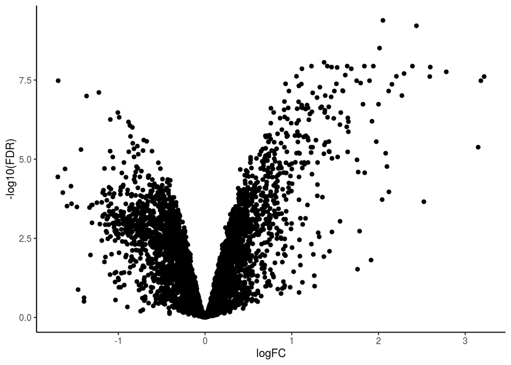

```r
gp <- distinct_df %>% filter(treatment == "AMB") %>%
  ggplot(aes(x = logFC, y = -log10(FDR))) + geom_point() + theme_classic()
gp
```

`ggplot2` predates most `tidyverse` packages, hence it uses the `+` to chain together `geoms` instead of `%>%`. It is compatible with the pipe symbol `%>%` which allows a filtered data-frame to be piped into the `ggplot` function.

We can overlay subsets of data onto the plot:

e.g highlight values with a logFC greater than 1

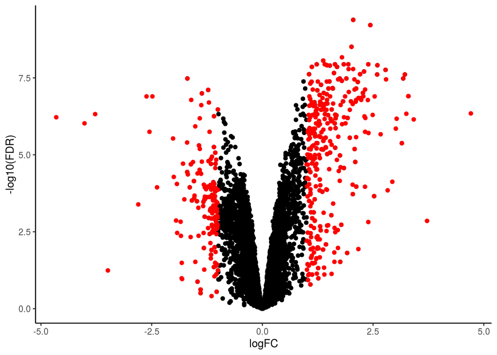

```r
gp + geom_point(data = filter(distinct_df, abs(logFC) > 1 ), color = "red")
```

Highlight values with a logFC greater than 1 and an FDR of less than 0.05

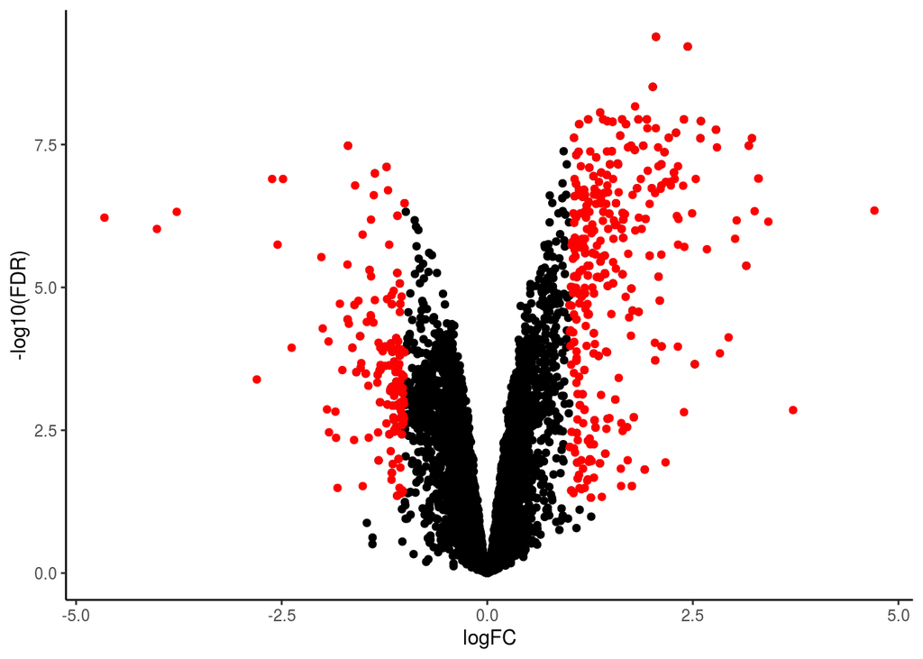

```r
gp + geom_point(data = filter(distinct_df, abs(logFC) > 1 & abs(FDR) < 0.05), color = "red")
```

Highlight a specific data point and add a label:

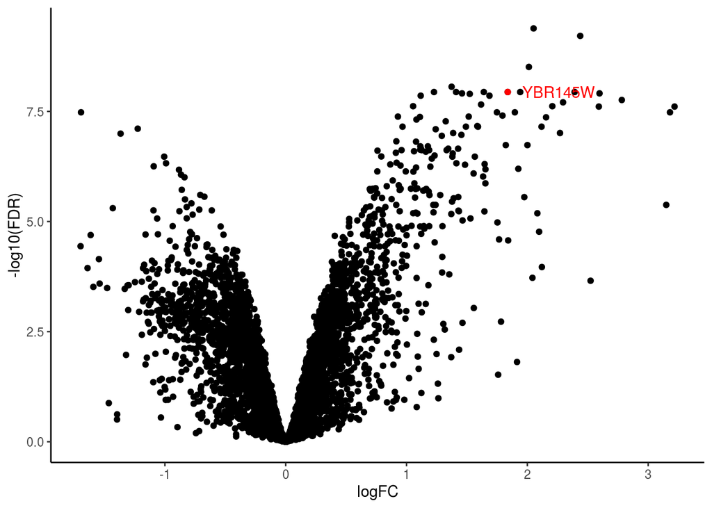

```
### Challenge

1. Identify the top 10 proteins with the largest logFC and label the name of these proteins onto the plot.
```

```r
gp + geom_point(data = filter(distinct_df, treatment == "AMB", gene_name == "ADH5"),
                color = "red") +
  geom_text(data = filter(distinct_df, treatment == "AMB", gene_name == "ADH5"),
            aes(label = oln_id),
            hjust = -0.2, color = "red")
```

We can plot the logFC values of each condition against the other:

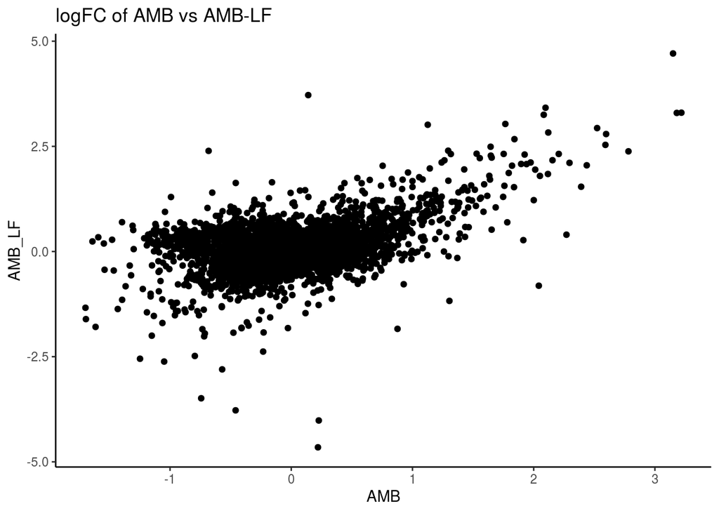

```r
distinct_df$treatment <- gsub(distinct_df$treatment, pattern = "-", replacement = "_")

logFC_df <- distinct_df %>% select(oln_id, treatment, logFC) %>%
  pivot_wider(id_cols = oln_id, names_from = treatment, values_from = logFC )

ggplot(logFC_df, aes(x = AMB, y= AMB_LF)) + geom_point() + ggtitle("logFC of AMB vs AMB-LF") +
  theme_classic()
```

## Mass Spec Dataset

Read the dataset in. This is also in an Excel spreadsheet but there is only one sheet this time.

```r
nuclear_xl_ms <- readxl::read_excel("data/Nuclear_XL_MS.xlsx")
head(nuclear_xl_ms)
```

| Protein1 | Protein2 | NameProtein1 | NameProtein2 | PPINovelty | PPIEvidenceInfoGroup | TotalNumberOfCSMs | NumberUniqueLysLysContacts |
| --- | --- | --- | --- | --- | --- | --- | --- |
| P02293 | P04911 | H2B1 | H2A1 | Known | Structure | 36 | 12 |
| P02293 | P02309 | H2B1 | H4 | Known | Structure | 21 | 6 |
| P02994 | P32471 | EF1A | EF1B | Known | Structure | 20 | 5 |
| P0CX51 | P38011 | RS16A | GBLP | Known | Structure | 13 | 1 |
| P02406 | P0CX49 | RL28 | RL18A | Novel | STRING | 13 | 2 |
| P33297 | P53549 | PRS6A | PRS10 | Known | Structure | 12 | 3 |

Examine the dataset with `str` and `summary`

```r
str(nuclear_xl_ms)
```

```
## Classes 'tbl_df', 'tbl' and 'data.frame':    228 obs. of  8 variables:
##  $ Protein1                  : chr  "P02293" "P02293" "P02994" "P0CX51" ...
##  $ Protein2                  : chr  "P04911" "P02309" "P32471" "P38011" ...
##  $ NameProtein1              : chr  "H2B1" "H2B1" "EF1A" "RS16A" ...
##  $ NameProtein2              : chr  "H2A1" "H4" "EF1B" "GBLP" ...
##  $ PPINovelty                : chr  "Known" "Known" "Known" "Known" ...
##  $ PPIEvidenceInfoGroup      : chr  "Structure" "Structure" "Structure" "Structure" ...
##  $ TotalNumberOfCSMs         : num  36 21 20 13 13 12 12 12 11 10 ...
##  $ NumberUniqueLysLysContacts: num  12 6 5 1 2 3 2 3 3 1 ...
```

```r
summary(nuclear_xl_ms)
```

```
##    Protein1           Protein2         NameProtein1       NameProtein2
##  Length:228         Length:228         Length:228         Length:228
##  Class :character   Class :character   Class :character   Class :character
##  Mode  :character   Mode  :character   Mode  :character   Mode  :character
##
##
##
##   PPINovelty        PPIEvidenceInfoGroup TotalNumberOfCSMs
##  Length:228         Length:228           Min.   : 1.000
##  Class :character   Class :character     1st Qu.: 1.000
##  Mode  :character   Mode  :character     Median : 1.000
##                                          Mean   : 2.706
##                                          3rd Qu.: 3.000
##                                          Max.   :36.000
##  NumberUniqueLysLysContacts
##  Min.   : 1.000
##  1st Qu.: 1.000
##  Median : 1.000
##  Mean   : 1.342
##  3rd Qu.: 1.000
##  Max.   :12.000
```

While the data in `PPINovelty` and `PPIEvidenceInfoGroup` are characters/strings, they can also be thought of as categorical.

```r
## Examine the unique values for the PPINovelty and PPIEvidenceInfoGroup columns
nuclear_xl_ms$PPINovelty %>% unique()
```

```
## [1] "Known" "Novel"
```

```r
nuclear_xl_ms$PPIEvidenceInfoGroup %>% unique()
```

```
## [1] "Structure"   "STRING"      "APID"        "Unexplained" "Genetic"
```

R has a class for categorical data known as factors. We can convert these columns to factors and provide an order to those categories (levels). By default, R will order the levels of a factor alphabetically but we can override this behaviour by defining the level order.

```r
nuclear_xl_ms <- nuclear_xl_ms %>% mutate(
  PPINovelty = factor(PPINovelty),
  PPIEvidenceInfoGroup = factor(PPIEvidenceInfoGroup, levels = c("Structure", "Genetic", "STRING", "APID", "Unexplained"))
)
nuclear_xl_ms %>% str()
```

```
## Classes 'tbl_df', 'tbl' and 'data.frame':    228 obs. of  8 variables:
##  $ Protein1                  : chr  "P02293" "P02293" "P02994" "P0CX51" ...
##  $ Protein2                  : chr  "P04911" "P02309" "P32471" "P38011" ...
##  $ NameProtein1              : chr  "H2B1" "H2B1" "EF1A" "RS16A" ...
##  $ NameProtein2              : chr  "H2A1" "H4" "EF1B" "GBLP" ...
##  $ PPINovelty                : Factor w/ 2 levels "Known","Novel": 1 1 1 1 2 1 2 1 1 1 ...
##  $ PPIEvidenceInfoGroup      : Factor w/ 5 levels "Structure","Genetic",..: 1 1 1 1 3 1 3 1 1 4 ...
##  $ TotalNumberOfCSMs         : num  36 21 20 13 13 12 12 12 11 10 ...
##  $ NumberUniqueLysLysContacts: num  12 6 5 1 2 3 2 3 3 1 ...
```

We can plot the Evidence codes or the Novelty counts with `geom_bar`

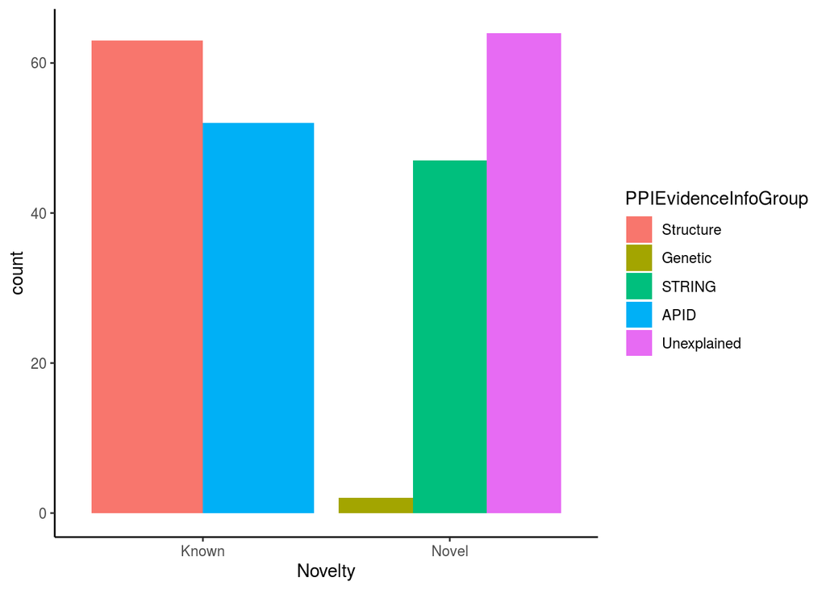

```r
ggplot(nuclear_xl_ms, aes(x = PPINovelty)) + geom_bar(aes(fill = PPIEvidenceInfoGroup),
                                                      position = "dodge") + xlab("Novelty") +
  theme_classic()
```

This plot looks a little strange. That’s because there are no Evidence codes that span both the ‘Known’ and "Novel’ category.

```r
# Create an example dataset
# note that the sample function will randomly retrieve 1000 values
# the resulting plot will look different everytime this code is run
novelty <- rep(c("Known", "Novel"), 2000) %>% sample(1000)
evidence <- rep(c("Structure", "Genetic", "STRING", "APID", "Unexplained"), 2000) %>% sample(1000)
example_data <- data.frame(novelty, evidence)
```

Summarise and plot:

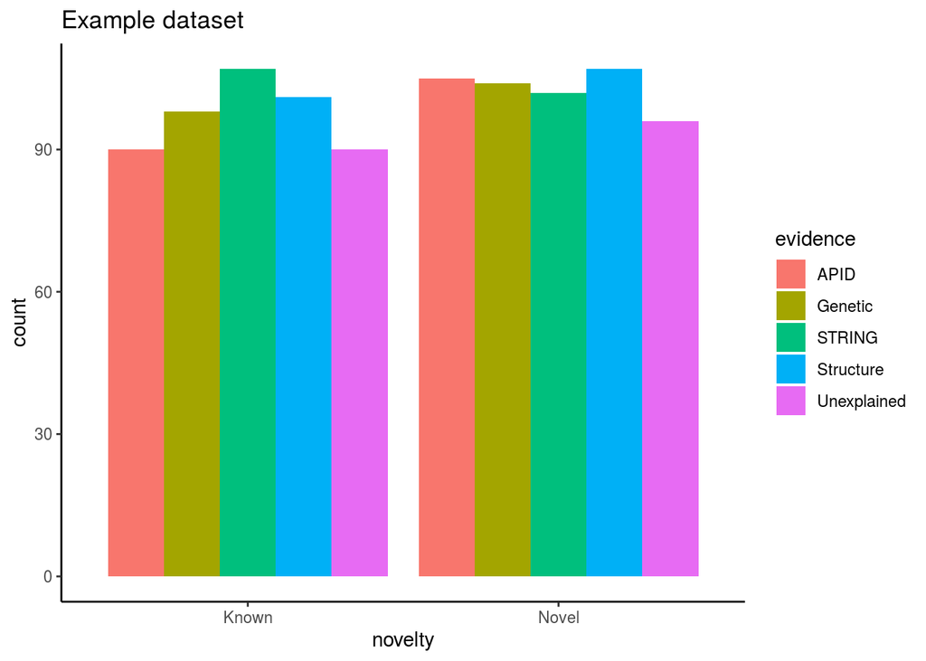

```r
ggplot(example_data, aes(novelty)) +
  geom_bar(aes(fill = evidence), position = "dodge") +
  ggtitle("Example dataset") + theme_classic()
```

(Also note, that since the `evidence` column contains character data and not a factor, the order of the bars is alphabetical)